- [Последняя версия](https://agricolamz.github.io/2019.08.01_ANDAN_GAM/index.html)
- [Исходный код](https://github.com/agricolamz/2019.08.01_ANDAN_GAM)

```r
library(tidyverse)
library(splines)
library(mgcv)

theme_set(theme_minimal()+theme(legend.position = "bottom"))
```

# 1 Полиномы, сплайны, GAM

[figure not shown]

## 1.1 Введение

Давайте на этой паре будем работать с таким абстрактным полиномом:

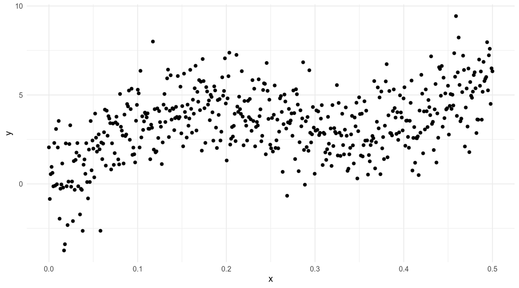

```r
set.seed(42)
poly <- tibble(x = seq(0, 0.5, length.out = 500),
               y = 0.2*x^9*(10*(1-x))^6+10*(10*x)^2*(1-x)^10+rnorm(500, sd = 1.5))

poly %>%
  ggplot(aes(x, y))+
  geom_point()
```

## 1.2 Полиномы

$y_i = \sum_{j=0}^k \beta_j \times x^j_i + \epsilon_i = \beta_0 \times x^0_0 + \beta_1 \times x^1_i + ... \beta_k \times x^k_i + \epsilon_i$

```r
poly_fit1 <- lm(y ~ poly(x, 2, raw = TRUE), data = poly)
poly_fit2 <- lm(y ~ x+I(x^2), data = poly)

summary(poly_fit1)
```

```
##
## Call:
## lm(formula = y ~ poly(x, 2, raw = TRUE), data = poly)
##
## Residuals:
##     Min      1Q  Median      3Q     Max
## -5.4650 -1.2176 -0.0068  1.2366  5.2724
##
## Coefficients:
##                         Estimate Std. Error t value Pr(>|t|)
## (Intercept)               1.5279     0.2325   6.572 1.26e-10 ***
## poly(x, 2, raw = TRUE)1  11.7709     2.1479   5.480 6.77e-08 ***
## poly(x, 2, raw = TRUE)2 -12.9025     4.1589  -3.102  0.00203 **
## ---
## Signif. codes:  0 '***' 0.001 '**' 0.01 '*' 0.05 '.' 0.1 ' ' 1
##
## Residual standard error: 1.74 on 497 degrees of freedom
## Multiple R-squared:  0.1777, Adjusted R-squared:  0.1744
## F-statistic:  53.7 on 2 and 497 DF,  p-value: < 2.2e-16
```

```r
summary(poly_fit2)
```

```
##
## Call:
## lm(formula = y ~ x + I(x^2), data = poly)
##
## Residuals:
##     Min      1Q  Median      3Q     Max
## -5.4650 -1.2176 -0.0068  1.2366  5.2724
##
## Coefficients:
##             Estimate Std. Error t value Pr(>|t|)
## (Intercept)   1.5279     0.2325   6.572 1.26e-10 ***
## x            11.7709     2.1479   5.480 6.77e-08 ***
## I(x^2)      -12.9025     4.1589  -3.102  0.00203 **
## ---
## Signif. codes:  0 '***' 0.001 '**' 0.01 '*' 0.05 '.' 0.1 ' ' 1
##
## Residual standard error: 1.74 on 497 degrees of freedom
## Multiple R-squared:  0.1777, Adjusted R-squared:  0.1744
## F-statistic:  53.7 on 2 and 497 DF,  p-value: < 2.2e-16
```

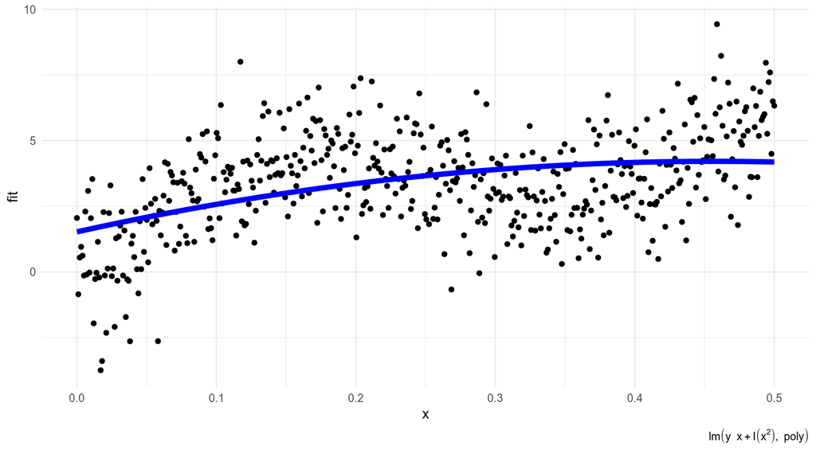

```r
tibble(x = poly$x,
       fit = poly_fit2$fitted.values) %>%
  ggplot(aes(x, fit))+
  geom_point(data = poly, aes(x, y))+
  geom_line(color = "blue", size = 2)+
  labs(caption = poly_fit2$call)
```

```r
poly_fit3 <- lm(y ~ poly(x, 3, raw = TRUE), data = poly)

summary(poly_fit3)
```

```
##
## Call:
## lm(formula = y ~ poly(x, 3, raw = TRUE), data = poly)
##
## Residuals:
##     Min      1Q  Median      3Q     Max
## -4.8629 -0.9488 -0.0517  0.9239  4.7424
##
## Coefficients:
##                          Estimate Std. Error t value Pr(>|t|)
## (Intercept)               -0.8437     0.2636  -3.201  0.00146 **
## poly(x, 3, raw = TRUE)1   68.9759     4.5695  15.095  < 2e-16 ***
## poly(x, 3, raw = TRUE)2 -299.2139    21.2489 -14.081  < 2e-16 ***
## poly(x, 3, raw = TRUE)3  381.7486    27.9340  13.666  < 2e-16 ***
## ---
## Signif. codes:  0 '***' 0.001 '**' 0.01 '*' 0.05 '.' 0.1 ' ' 1
##
## Residual standard error: 1.484 on 496 degrees of freedom
## Multiple R-squared:  0.4026, Adjusted R-squared:  0.399
## F-statistic: 111.4 on 3 and 496 DF,  p-value: < 2.2e-16
```

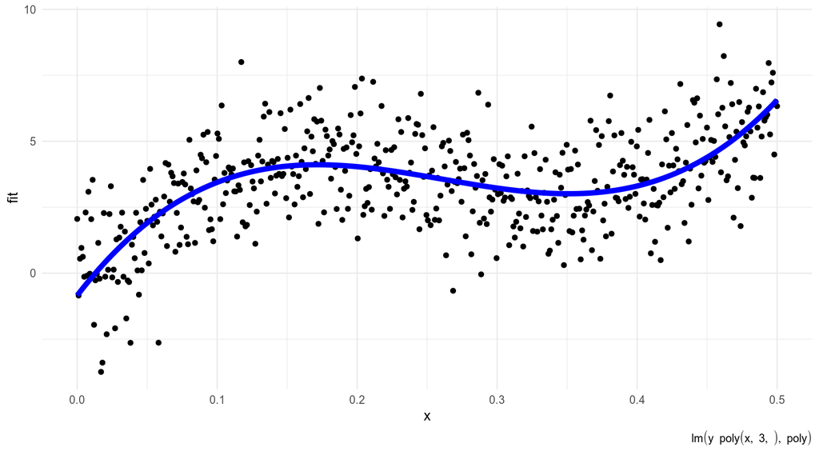

```r
tibble(x = poly$x,
       fit = poly_fit3$fitted.values) %>%
  ggplot(aes(x, fit))+
  geom_point(data = poly, aes(x, y))+
  geom_line(color = "blue", size = 2)+
  labs(caption = poly_fit3$call)
```

> [Загрузите данные](https://raw.githubusercontent.com/agricolamz/2019.08.01_ANDAN_GAM/master/data/sales-of-shampoo-over-a-three-ye.csv) по продаже шампуня [(Makridakis, Wheelwright and Hyndman 1998)](https://www.kaggle.com/djokester/sales-of-shampoo-over-a-three-year-period), используя функцию `read_csv()`. Постройте регрессию, моделирующую связь между переменными полиномом второй степени. В ответе превидите предсказание модели для 42 дня (с точностью до двух знаков после запятой).

> [Загрузите данные](https://raw.githubusercontent.com/agricolamz/2019.08.01_ANDAN_GAM/master/data/avocado.csv) по продаже авакадо (см. [исходное описание](https://www.kaggle.com/neuromusic/avocado-prices)). Визуализируйте полученные данные (x = `Date`, y = `AveragePrice`, color = `type`), сделайте фасетизацию по переменной `region`, а при помощи функции `geom_smooth(method = "lm", formula = ...` нанесите на график полиномы 12-ой степени. В каком регионе, как кажется, наименьший разрыв в средней цене обычных и органических авокадо.

## 1.3 Сплайны

Альтернативный подход: сделать кусочную функцию. В результате данные делятся на узлы (knots), и в каждом узле получившаяся функция, а также ее первая и вторая производная должны быть плавными.

```r
library(splines)
poly_fit3 <- lm(y ~ bs(x), data = poly)
summary(poly_fit3)
```

```
##
## Call:
## lm(formula = y ~ bs(x), data = poly)
##
## Residuals:
##     Min      1Q  Median      3Q     Max
## -4.8629 -0.9488 -0.0517  0.9239  4.7424
##
## Coefficients:
##             Estimate Std. Error t value Pr(>|t|)
## (Intercept)  -0.8437     0.2636  -3.201  0.00146 **
## bs(x)1       11.4960     0.7616  15.095  < 2e-16 ***
## bs(x)2       -1.9425     0.4835  -4.018 6.78e-05 ***
## bs(x)3        7.4030     0.4161  17.792  < 2e-16 ***
## ---
## Signif. codes:  0 '***' 0.001 '**' 0.01 '*' 0.05 '.' 0.1 ' ' 1
##
## Residual standard error: 1.484 on 496 degrees of freedom
## Multiple R-squared:  0.4026, Adjusted R-squared:  0.399
## F-statistic: 111.4 on 3 and 496 DF,  p-value: < 2.2e-16
```

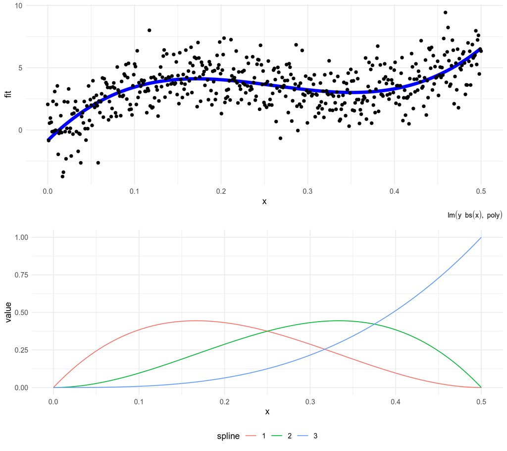

```r
tibble(x = poly$x,
       fit = poly_fit3$fitted.values) %>%
  ggplot(aes(x, fit))+
  geom_line(color = "blue", size = 2)+
  geom_point(data = poly, aes(x, y))+
  labs(caption = poly_fit3$call) ->
  p1

as_tibble(cbind(bs(poly$x), x = poly$x)) %>%
  gather(spline, value, -x) %>%
  ggplot(aes(x, value, color = spline))+
  geom_line() ->
  s1

gridExtra::grid.arrange(p1, s1)
```

```r
poly_fit4 <- lm(y ~ bs(x, knots = 5), data = poly)
summary(poly_fit4)
```

```
##
## Call:
## lm(formula = y ~ bs(x, knots = 5), data = poly)
##
## Residuals:
##     Min      1Q  Median      3Q     Max
## -4.8629 -0.9488 -0.0517  0.9239  4.7424
##
## Coefficients: (1 not defined because of singularities)
##                   Estimate Std. Error t value Pr(>|t|)
## (Intercept)        -0.8437     0.2636  -3.201  0.00146 **
## bs(x, knots = 5)1  11.4960     0.7616  15.095  < 2e-16 ***
## bs(x, knots = 5)2  -1.9425     0.4835  -4.018 6.78e-05 ***
## bs(x, knots = 5)3   7.4030     0.4161  17.792  < 2e-16 ***
## bs(x, knots = 5)4       NA         NA      NA       NA
## ---
## Signif. codes:  0 '***' 0.001 '**' 0.01 '*' 0.05 '.' 0.1 ' ' 1
##
## Residual standard error: 1.484 on 496 degrees of freedom
## Multiple R-squared:  0.4026, Adjusted R-squared:  0.399
## F-statistic: 111.4 on 3 and 496 DF,  p-value: < 2.2e-16
```

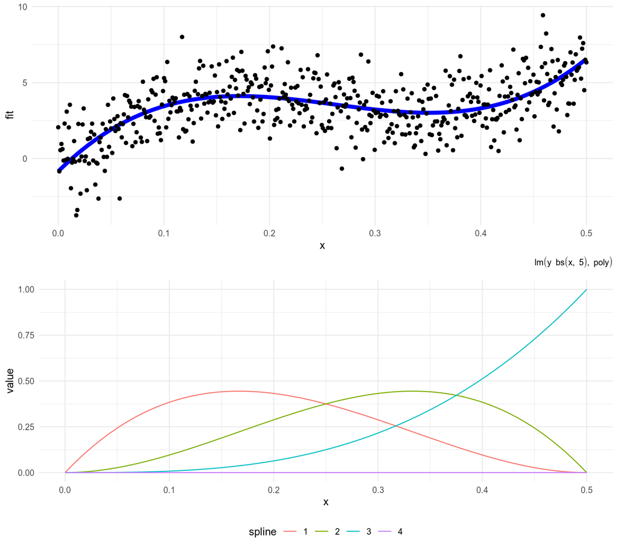

```r
tibble(x = poly$x,
       fit = poly_fit4$fitted.values) %>%
  ggplot(aes(x, fit))+
  geom_line(color = "blue", size = 2)+
  geom_point(dat = poly, aes(x,y))+
  labs(caption = poly_fit4$call) ->
  p2

as_tibble(cbind(bs(poly$x, knots = 5), x = poly$x)) %>%
  gather(spline, value, -x) %>%
  ggplot(aes(x, value, color = spline))+
  geom_line() ->
  s2

gridExtra::grid.arrange(p2, s2)
```

```r
poly_fit5 <- lm(y ~ bs(x, degree = 5), data = poly)
summary(poly_fit5)
```

```
##
## Call:
## lm(formula = y ~ bs(x, degree = 5), data = poly)
##
## Residuals:
##     Min      1Q  Median      3Q     Max
## -4.4925 -0.9958  0.0199  0.9923  4.4759
##
## Coefficients:
##                    Estimate Std. Error t value Pr(>|t|)
## (Intercept)         0.03152    0.38659   0.082   0.9350
## bs(x, degree = 5)1  1.72723    1.56785   1.102   0.2711
## bs(x, degree = 5)2 13.75698    1.99809   6.885 1.76e-11 ***
## bs(x, degree = 5)3 -5.86063    2.39313  -2.449   0.0147 *
## bs(x, degree = 5)4  4.75438    1.19050   3.994 7.50e-05 ***
## bs(x, degree = 5)5  5.80448    0.58906   9.854  < 2e-16 ***
## ---
## Signif. codes:  0 '***' 0.001 '**' 0.01 '*' 0.05 '.' 0.1 ' ' 1
##
## Residual standard error: 1.466 on 494 degrees of freedom
## Multiple R-squared:  0.4197, Adjusted R-squared:  0.4138
## F-statistic: 71.45 on 5 and 494 DF,  p-value: < 2.2e-16
```

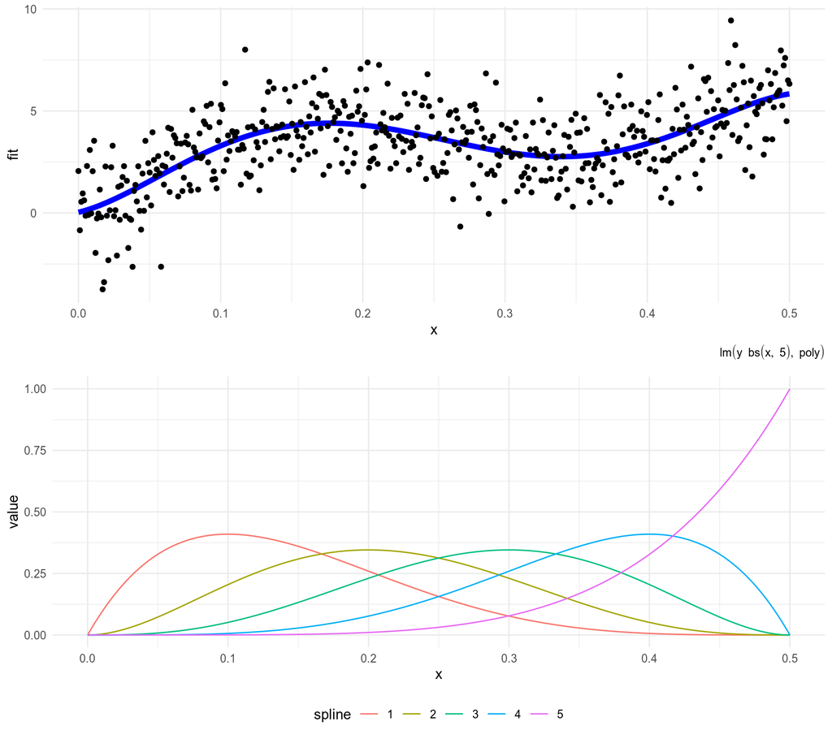

```r
tibble(x = poly$x,
       fit = poly_fit5$fitted.values) %>%
  ggplot(aes(x, fit))+
  geom_line(color = "blue", size = 2)+
  geom_point(dat = poly, aes(x,y))+
  labs(caption = poly_fit5$call) ->
  p3

as_tibble(cbind(bs(poly$x, degree = 5), x = poly$x)) %>%
  gather(spline, value, -x) %>%
  ggplot(aes(x, value, color = spline))+
  geom_line() ->
  s3

gridExtra::grid.arrange(p3, s3)
```

> [Загрузите данные](https://raw.githubusercontent.com/agricolamz/2019.08.01_ANDAN_GAM/master/data/sales-of-shampoo-over-a-three-ye.csv) по продаже шампуня [(Makridakis, Wheelwright and Hyndman 1998)](https://www.kaggle.com/djokester/sales-of-shampoo-over-a-three-year-period), используя функцию `read_csv()`. Постройте регрессию, моделирующую связь между переменными сплайнами второй степени. В ответе превидите предсказание модели для 42 дня (с точностью до двух знаков после запятой).

## 1.4 GAM

### 1.4.1 Что такое GAM

Согласно теореме Колмогорова – Арнольда, каждая непрерывная функция может быть представлена в виде композиции непрерывных функций одной переменной. Композиция — применение одной функции к результатам другой: $(G\circ F)(x) = G(F(x))$. Подробнее см. [лекции Виктора Клепцына](https://forany.xyz/a-453). Проблема осталась только одна: эта формула не дает никакого инсайта по поводу того, как эту функциб получить. На практике фитят теми же кубическими сплайнами (но не обязательно), используя [Backfitting algorithm](https://en.wikipedia.org/wiki/Backfitting_algorithm).

### 1.4.2 Ваш первый GAM

```r
library(mgcv)
poly_fit4 <- gam(y ~ s(x), data = poly)
summary(poly_fit4)
```

```
##
## Family: gaussian
## Link function: identity
##
## Formula:
## y ~ s(x)
##
## Parametric coefficients:
##             Estimate Std. Error t value Pr(>|t|)
## (Intercept)  3.39434    0.06571   51.66   <2e-16 ***
## ---
## Signif. codes:  0 '***' 0.001 '**' 0.01 '*' 0.05 '.' 0.1 ' ' 1
##
## Approximate significance of smooth terms:
##        edf Ref.df     F p-value
## s(x) 5.044  6.145 55.26  <2e-16 ***
## ---
## Signif. codes:  0 '***' 0.001 '**' 0.01 '*' 0.05 '.' 0.1 ' ' 1
##
## R-sq.(adj) =  0.411   Deviance explained = 41.7%
## GCV =  2.185  Scale est. = 2.1586    n = 500
```

edf – effective degrees of freedom (edf = 1 — прямая, edf = 2 — полином второй степени и т. д.) Высокий edf не значит статистическую значимость: высокий edf может не иметь статистической значимости и наоборот.

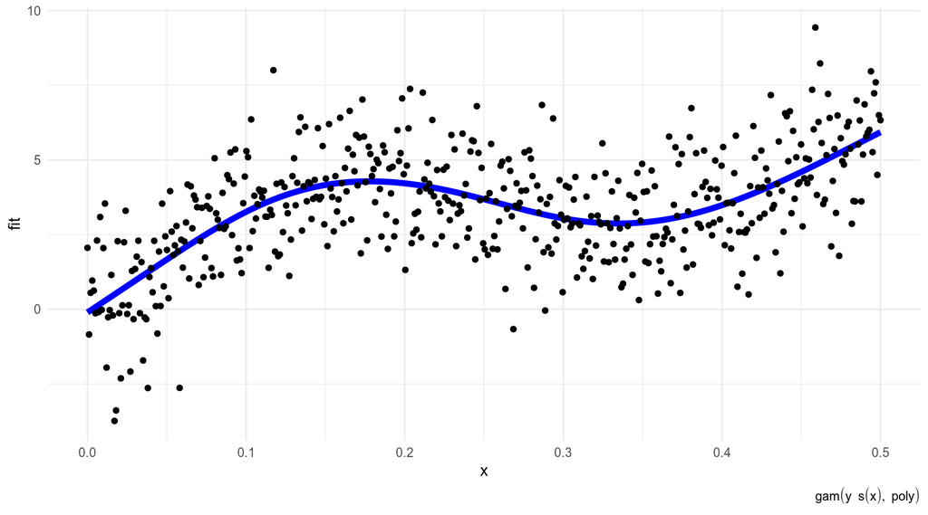

```r
tibble(x = poly$x,
       fit = poly_fit4$fitted.values) %>%
  ggplot(aes(x, fit))+
  geom_line(color = "blue", size = 2)+
  geom_point(data = poly, aes(x, y))+
  labs(caption = poly_fit4$call)
```

> В пакете `mgcv` достаточно много усилий положено для визуализации, так что имеет смысл посмотреть `?plot.gam`. Когда вы рисуете модель используйте аргумент `plot(your_model, all.terms = TRUE)`

### 1.4.3 Параметры сглаживания

В GAM два параметра сглаживания:

- коэффициент сглаживания
- количество функций, которыми сглаживается

#### 1.4.3.1 Настройка коэффициента сглаживания:

- слишком большой

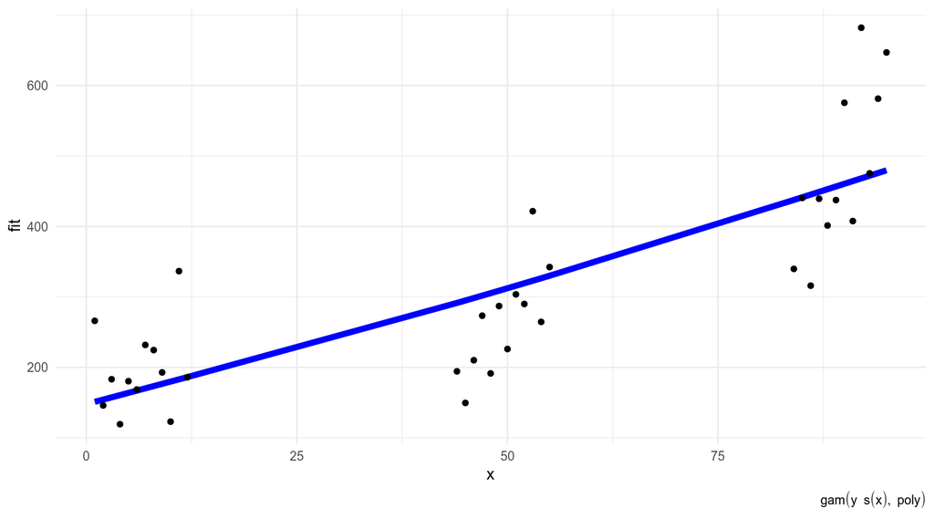

```r
tibble(x = shampoo$day,
       fit = gam(sales_of_shampoo ~ s(day, sp = 50), data = shampoo)$fitted.values) %>%
  ggplot(aes(x, fit))+
  geom_line(color = "blue", size = 2)+
  geom_point(data = shampoo, aes(day, sales_of_shampoo))+
  labs(caption = poly_fit4$call)
```

- слишком маленький

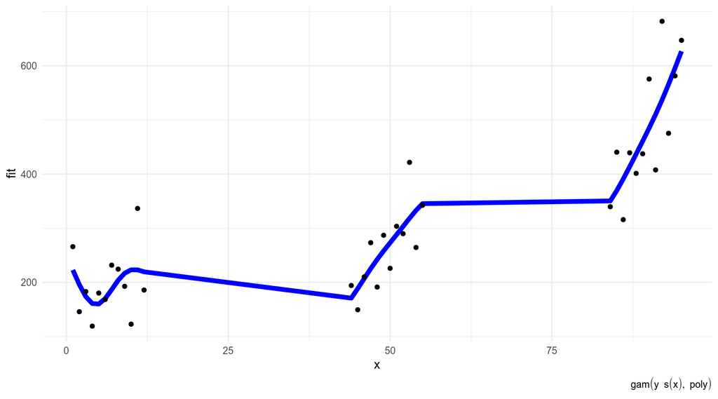

```r
tibble(x = shampoo$day,
       fit = gam(sales_of_shampoo ~ s(day, sp = 1e-5), data = shampoo)$fitted.values) %>%
  ggplot(aes(x, fit))+
  geom_line(color = "blue", size = 2)+
  geom_point(data = shampoo, aes(day, sales_of_shampoo))+
  labs(caption = poly_fit4$call)
```

- в самый раз… наверное…

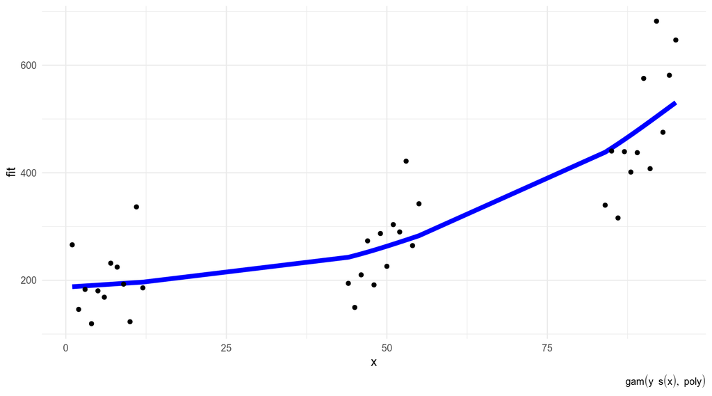

```r
tibble(x = shampoo$day,
       fit = gam(sales_of_shampoo ~ s(day, sp = 0.5), data = shampoo)$fitted.values) %>%
  ggplot(aes(x, fit))+
  geom_line(color = "blue", size = 2)+
  geom_point(data = shampoo, aes(day, sales_of_shampoo))+
  labs(caption = poly_fit4$call)
```

- а вот что выдает хваленный `method = "REML"`:

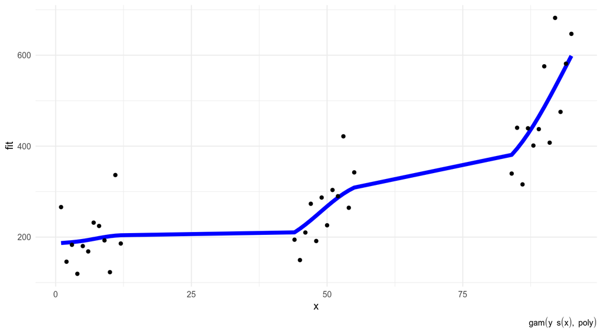

```r
tibble(x = shampoo$day,
       fit = gam(sales_of_shampoo ~ s(day), data = shampoo, method = "REML")$fitted.values) %>%
  ggplot(aes(x, fit))+
  geom_line(color = "blue", size = 2)+
  geom_point(data = shampoo, aes(day, sales_of_shampoo))+
  labs(caption = poly_fit4$call)
```

#### 1.4.3.2 Настройка количества базовых функций:

Не может превышать количества наблюдений.

- слишком много

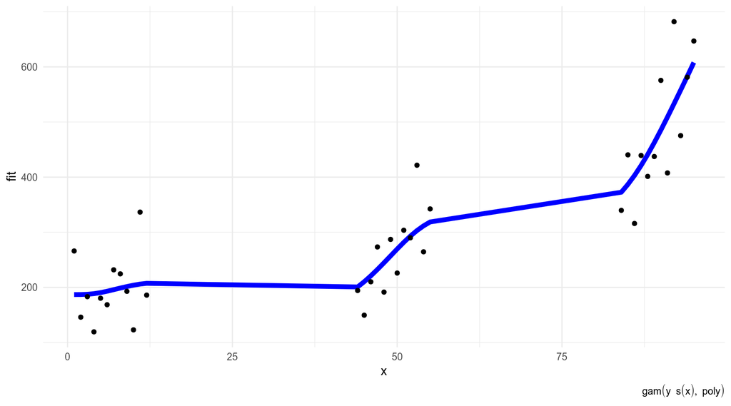

```r
tibble(x = shampoo$day,
       fit = gam(sales_of_shampoo ~ s(day, k = 30), data = shampoo)$fitted.values) %>%
  ggplot(aes(x, fit))+
  geom_line(color = "blue", size = 2)+
  geom_point(data = shampoo, aes(day, sales_of_shampoo))+
  labs(caption = poly_fit4$call)
```

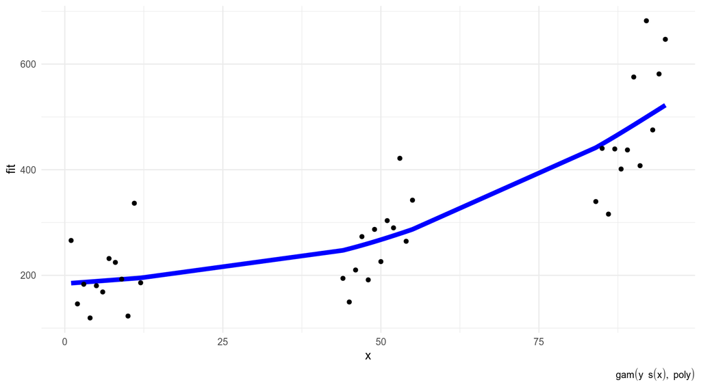

```r
tibble(x = shampoo$day,
       fit = gam(sales_of_shampoo ~ s(day, sp = 1), data = shampoo)$fitted.values) %>%
  ggplot(aes(x, fit))+
  geom_line(color = "blue", size = 2)+
  geom_point(data = shampoo, aes(day, sales_of_shampoo))+
  labs(caption = poly_fit4$call)
```